# Bang the Can Slowly: An Investigation into the 2017 Houston Astros

Ryan Elmore and Gregory J. Matthews  
October 29, 2020

### Sign Stealing

- In baseball, it is helpful for the the catcher to know the type of pitch that the pitcher will throw.
- In order to communicate this information, the catcher will flash signs to the pitcher with his hand between his legs.
- It is important for the pitcher and catcher that the batter does not know the type of pitch that is coming as batter uncertainty about the type of the pitch is an important tool in a pitchers arsenal.

### Sign Stealing

[figure not shown]

### How did the Astros steal signs?

[figure not shown]

### Did it actually affect the game?

- “**Our opinion is this didn't impact the game**. We had a good team. We won the World Series and we'll leave it at that” - Jim Crane, Houston Astros owner, February 13, 2020
- So…..did it affect the game?
- How can we answer this quesion?
  - Ideal data: Pitch-level data with information about…
    - Type of pitch
    - Pitch outcome (Batter Swing? Batter Contact?)
    - Exit Velocity
    - **Was there a bang on the pitch?** (Thank you, Tony Adams!)

### Which players received the most stolen signs?

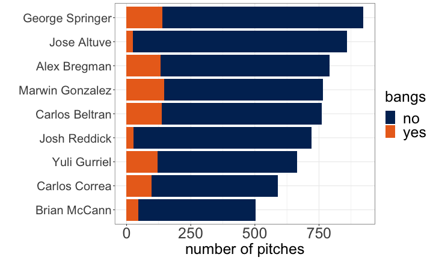

### Bangs over the season

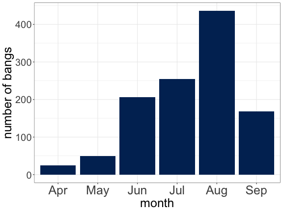

### How good was the scheme?

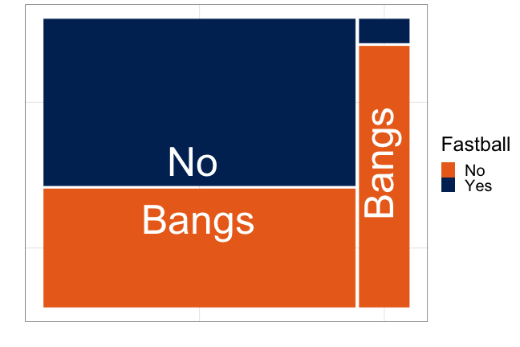

### Swinging

```
       has_bangs
swing       No    Yes
  swing 0.4621 0.4053
  take  0.5379 0.5947
```

```
    Pearson's Chi-squared test with Yates' continuity correction

data:  .
X-squared = 12.569, df = 1, p-value = 0.0003922
```

```
[1] 1.260811
```

### Contact

```
          has_bangs
is_contact     No    Yes
         0 0.1974 0.2056
         1 0.8026 0.7944
```

```
    Pearson's Chi-squared test with Yates' continuity correction

data:  .
X-squared = 0.12569, df = 1, p-value = 0.7229
```

```
[1] 0.9499327
```

### Contact - Not Fastballs

```
          has_bangs
is_contact     No    Yes
         0 0.3028 0.2077
         1 0.6972 0.7923
```

```
    Pearson's Chi-squared test with Yates' continuity correction

data:  .
X-squared = 13.603, df = 1, p-value = 0.0002258
```

```
[1] 1.656225
```

### Exit Velocity

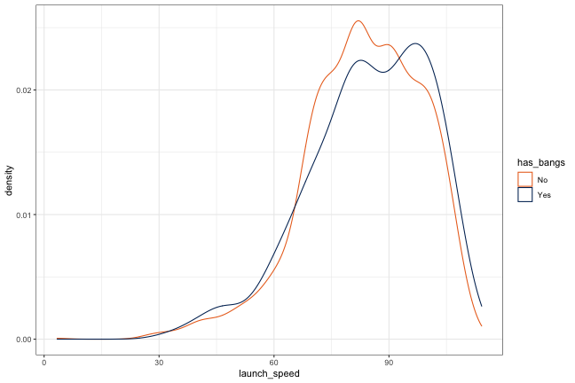

### Models

1. Swing model
   - Fixed effects: fastball, called strike probability and count
   - Random effect: intercept for batter
2. Contact model given a swing
   - Fixed effects: fastball, called strike probability, and interaction between fastball and bangs
   - Random effects: intercepts for batter and pitcher, and bangs slope for batters
3. Exit Velocity model given a contact
   - Fixed effects: fastball and called strike probability
   - Random effects: intercepts for batter and pitcher

### Increased Exit velocity

- A ball hit with exit velocity of 100 mph at a launch angle of 30 degrees will travel about 385.3 feet before landing.
- A ball hit with exit velocity of 102.386 mph at a launch angle of 30 degrees will travel about 397.9 feet (i.e. 12.6 additional feet) before landing.
- This is the difference between a longfly ball to straight away center field (likely an out) and a home run at Fenway Park, where home run is 389' 9" inches to center field

### Not everyone benefitted equally

```
               name         int     slope
1   George Springer -0.55640079 1.3376009
2  Yulieski Gurriel -0.03004136 0.9501957
3    Jonathan Davis -0.88495348 0.8822223
4   Jacob Marisnick -0.80047348 0.8658479
5      James Gattis -0.21505850 0.7177546
6   William Reddick  0.05626790 0.6981152
7        Max Stassi -0.20029400 0.6409230
8     Carlos Correa -0.15135564 0.6229918
9    Carlos Beltran -0.01088927 0.6139698
10     Juan Centeno -0.22230871 0.5841716
```

### Curious, George

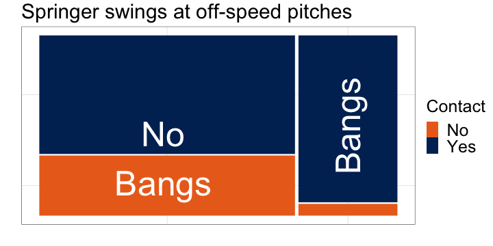

### Conclusions

**In the presence of a bang…**

### Future Work

- Quantify the **value** of the bangs. I want to be able to say something like:
  - “The Astros gained X runs over the course of the season”
  - “The Astros gained X wins over the course of the season”
- Can we detect when the scheme was on and when it was off? Right now the absence of a bang can either mean the scheme was off OR that the scheme was on and a fastball was coming.
- Can we detect sign stealing **without** the bangs?

### Cheers!

- Ryan Elmore (@rtelmore)
- Gregory J. Matthews (@statsinthewild)
- Github Repo: gjm112/Astros_sign_stealing
- Bangs Data: http://signstealingscandal.com/files/
- Harry Pavlidis and Baseball Prospectus